# Lab06

John Kaspers

June 15, 2020

#### Warning

**Warning:** If you get an error when running the code, make sure that you have the necessary packages installed. You can install them by running the following code in base R (not RStudio or RMarkdown).

> install.packages(‘alr4’)  
> install.packages(‘effects’)

### Challenger Space Shuttle

For this lab, we’ll be using the `Challeng` data set from the `alr4` package. Further information on the data set can be found [here](https://www.rdocumentation.org/packages/alr4/versions/1.0.5/topics/Challeng).

1. In the `Challeng` data set, the variable `fail` represents the **number** of O-rings that failed during prior flights. Use the `ifelse()` function (similar to the Lab 06 Example script) to create a new binary variable `failed`, where 0 will represent observations with no failed O-rings and 1 will represent observations with any (1 or more) failed O-rings.

```r
data(Challeng, package = "alr4")

Challeng$failed <- ifelse(Challeng$fail >= 1, 1, 0)
Challeng$failed
```

```
##  [1] 0 1 0 0 0 0 0 0 1 1 1 0 0 1 0 0 0 0 0 0 1 0 1
```

2. Create a logistic regression model that predicts your new binary variable `failed` with the variable `temp` (temperature in degrees F).

```r
lr.challenge <- glm(failed ~ temp, data = Challeng, family = "binomial")
summary(lr.challenge)
```

```
##
## Call:
## glm(formula = failed ~ temp, family = "binomial", data = Challeng)
##
## Deviance Residuals:
##     Min       1Q   Median       3Q      Max
## -1.0611  -0.7613  -0.3783   0.4524   2.2175
##
## Coefficients:
##             Estimate Std. Error z value Pr(>|z|)
## (Intercept)  15.0429     7.3786   2.039   0.0415 *
## temp         -0.2322     0.1082  -2.145   0.0320 *
## ---
## Signif. codes:  0 '***' 0.001 '**' 0.01 '*' 0.05 '.' 0.1 ' ' 1
##
## (Dispersion parameter for binomial family taken to be 1)
##
##     Null deviance: 28.267  on 22  degrees of freedom
## Residual deviance: 20.315  on 21  degrees of freedom
## AIC: 24.315
##
## Number of Fisher Scoring iterations: 5
```

For the following two questions, provide the numerical value that would make each statement correct.

3. For a one-degree increase in temperature (in deg F), we would estimate a *decrease* of (___) in the **log odds** of an O-ring failing, on average.

0.23

4. For a one-degree increase in temperature (in deg F), we would estimate a *decrease* of (___)% in the **odds** of an O-ring failing, on average.

e^(-0.23) = 0.792788 1- 0.792788 = 20.7%

5. Visualize the relationship. Create a plot of the probability of an O-ring failure versus the temperature (Y vs X). Give appropriate labels for the x and y-axes. See the Lab 06 Example script for help!

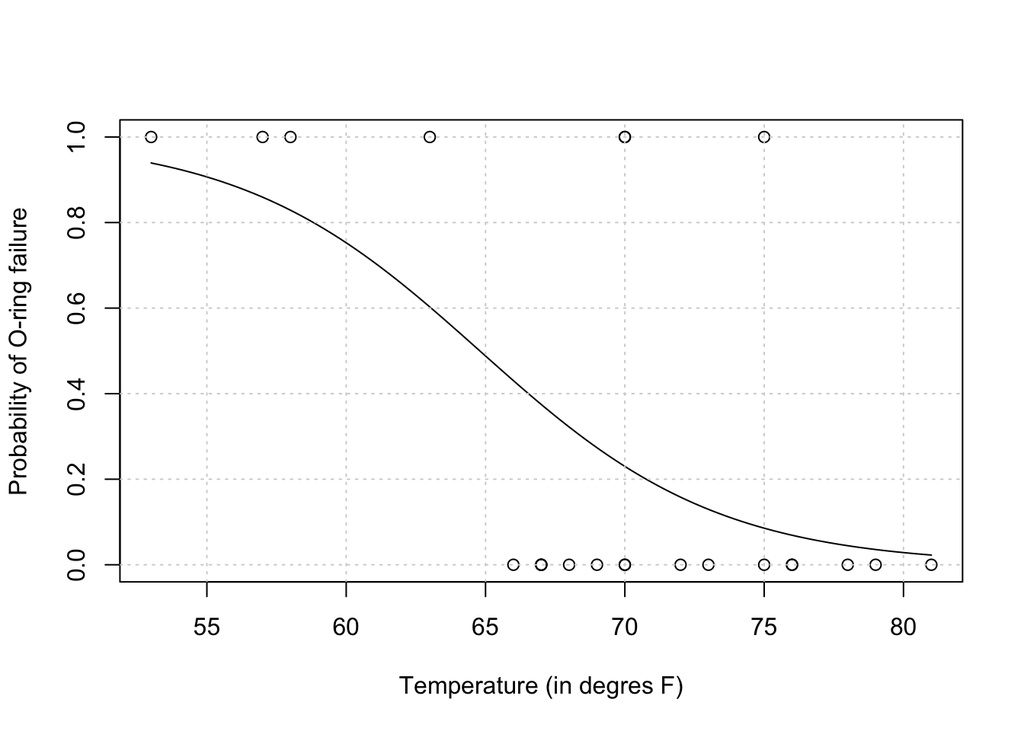

```r
x.temp <- seq(min(Challeng$temp), max(Challeng$temp), len = 100)
y.temp <- predict(lr.challenge, data.frame(temp = x.temp), type = "response")

plot(Challeng$temp, Challeng$failed,
     xlab = "Temperature (in degres F)",
     ylab = "Probability of O-ring failure")
lines(x.temp, y.temp)
grid()
```

6. At approximately what temperature is the probability of failure 90%? (Just eyeball the y-value.)

7. Use the `predict()` function to predict the probability of an O-ring failure when the temperature is 31 degrees (F) - the launch temperature on Jan 20, 1986.

```r
predict(lr.challenge, data.frame(temp = 31), type = "response")
```

```
##         1
## 0.9996088
```

8. Create a second logistic regresison model that predicts `failed` with `temp` and `pres`. Use the `anova()` function to determine if this new model is an improvement (using a significance level of 5%) over the first model.

```r
lr.challenge2 <- glm(failed ~ temp + pres, data = Challeng, family = "binomial")
anova(lr.challenge, lr.challenge2, test = "LRT")
```

```
## Analysis of Deviance Table
##
## Model 1: failed ~ temp
## Model 2: failed ~ temp + pres
##   Resid. Df Resid. Dev Df Deviance Pr(>Chi)
## 1        21     20.315
## 2        20     18.972  1   1.3436   0.2464
```

9. What is the resulting p-value? Is the second model an improvement from the first?

The p-value is 0.2464. At a 5% level, the second model which used temp and pres as predictors is not a statistically significant improvement over the first model (which used just temp as a predictor).

10. When the model has multiple variables, we can use the `predictorEffects()` function in the `effects` package to visualize the individual relationships. Visualize the effects of `temp` and `pres` in your second model. Remember that you should include the argument `rescale.axis = FALSE` in your code. These plots should confirm your answer to Part 9.

```r
library(effects)
```

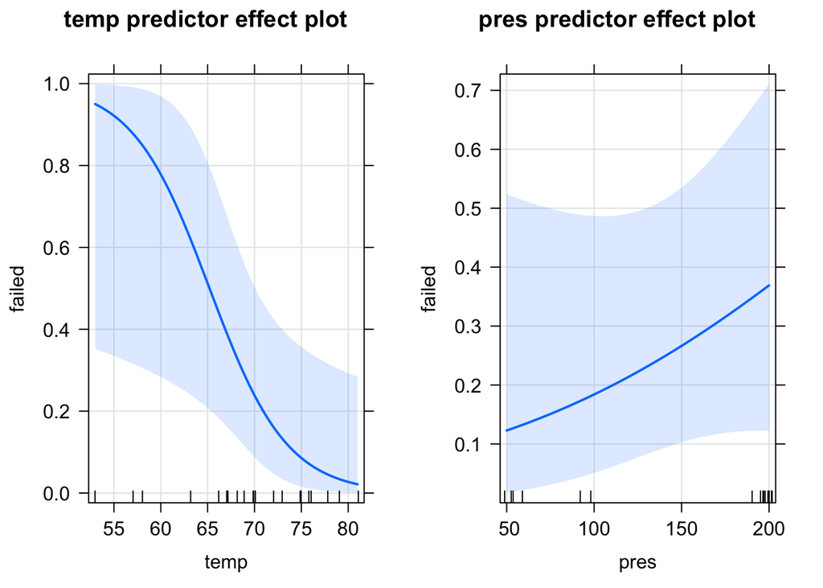

```r
plot(predictorEffects(lr.challenge2), rescale.axis = FALSE, grid = TRUE)
```